# IODS course project

ph

# About the project

This is a first assignment of the Introduction to Open Data Science 2018 course. Git / rstudio / rmarkdown exercises.

[Github for this exercise](https://github.com/phcourses/IODS-project)

# Chapter 2: Week 2 regression analysis

```r
library(data.table)

# Read in learning2014 created with create_learning2014.R
learning2014<-fread("learning2014.txt")
```

### Dimensions and variable characteristics of learning2014

```r
# Number of records and number of variables in the dataset
dim(learning2014)
```

```
## [1] 166   7
```

```r
# Variable types (integers are integer variables, numerical are continuous floating number variables)
str(learning2014)
```

```
## Classes 'data.table' and 'data.frame':   166 obs. of  7 variables:
##  $ Gender  : int  2 1 2 1 1 2 1 2 1 2 ...
##  $ Age     : int  53 55 49 53 49 38 50 37 37 42 ...
##  $ Attitude: int  37 31 25 35 37 38 35 29 38 21 ...
##  $ Deep    : num  3.58 2.92 3.5 3.5 3.67 ...
##  $ Stra    : num  3.38 2.75 3.62 3.12 3.62 ...
##  $ Surf    : num  2.58 3.17 2.25 2.25 2.83 ...
##  $ Points  : int  25 12 24 10 22 21 21 31 24 26 ...
##  - attr(*, ".internal.selfref")=<externalptr>
```

Gender: Male = 1, Female = 2  
Age: Age (in years) derived from the date of birth  
Attitude: Global attitude toward statistics  
Deep: Deep approach  
Stra: Strategic approach  
Surf: Surface approach  
Points: Yhteispisteet (max kaikista)

### Variable summary statistics

```r
summary(learning2014)
```

```
##      Gender           Age           Attitude          Deep
##  Min.   :1.000   Min.   :17.00   Min.   :14.00   Min.   :1.583
##  1st Qu.:1.000   1st Qu.:21.00   1st Qu.:26.00   1st Qu.:3.333
##  Median :2.000   Median :22.00   Median :32.00   Median :3.667
##  Mean   :1.663   Mean   :25.51   Mean   :31.43   Mean   :3.680
##  3rd Qu.:2.000   3rd Qu.:27.00   3rd Qu.:37.00   3rd Qu.:4.083
##  Max.   :2.000   Max.   :55.00   Max.   :50.00   Max.   :4.917
##       Stra            Surf           Points
##  Min.   :1.250   Min.   :1.583   Min.   : 7.00
##  1st Qu.:2.625   1st Qu.:2.417   1st Qu.:19.00
##  Median :3.188   Median :2.833   Median :23.00
##  Mean   :3.121   Mean   :2.787   Mean   :22.72
##  3rd Qu.:3.625   3rd Qu.:3.167   3rd Qu.:27.75
##  Max.   :5.000   Max.   :4.333   Max.   :33.00
```

### Histograms of variables to visualizes distribution shape

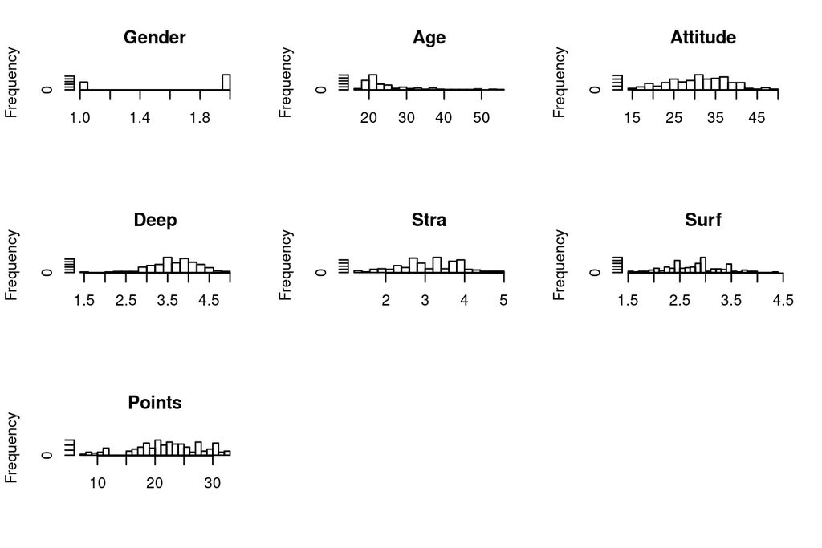

```r
par(mfrow=c(3,3))
sapply(1:ncol(learning2014),function(i) hist(learning2014[[i]], breaks=20, xlab=NA,main=names(learning2014)[i]))
```

### Density plots

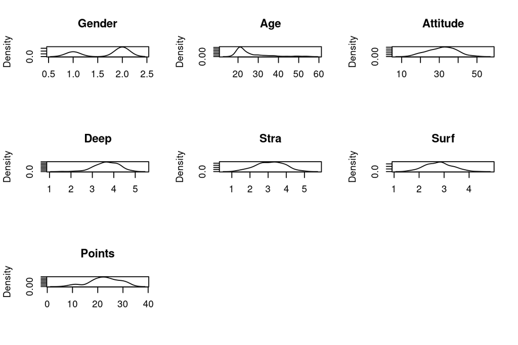

```r
par(mfrow=c(3,3))
sapply(1:ncol(learning2014),function(i) plot(density(learning2014[[i]]), xlab=NA,main=names(learning2014)[i]))
```

Age has a long right tail. Attitude, Deep, Stra, and Surf could be considered approximately normally distributed. From Surf and Stra histograms we can clearly see that they are sum variables and have multiple modes (peaks in the histogram).

### Pairwise relationships between variables

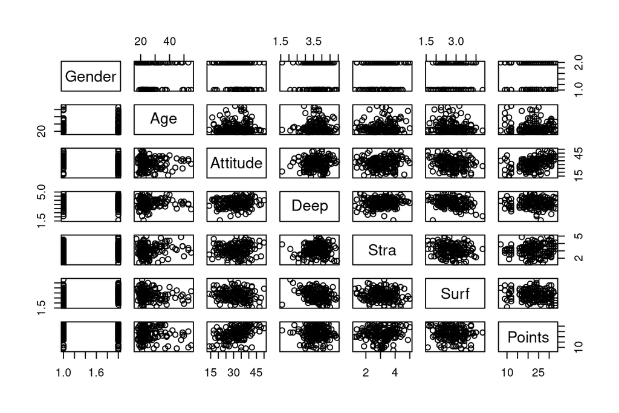

```r
pairs(learning2014)
```

Visually at least Attitude seems to have relationship with Points. To further investigate this, let’s additionally draw a correlation plot.

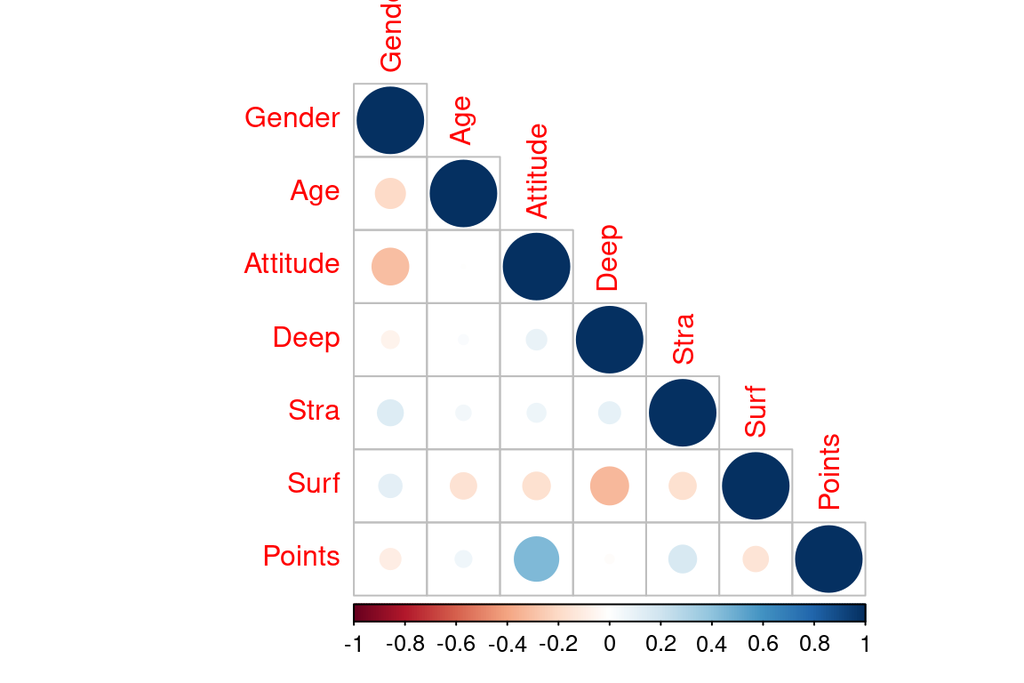

```r
library(corrplot)
corrplot(cor(learning2014, method="spearman"), type="lower")
```

Attitude clearly correlates with Points. Furthermore, Age, gender, stra, and surf all seem to have a small correlation. Given we are allowed to choose only three variables for this exercise, age and gender with attitude seem most interesting combination.

### Linear regression model

Lets try first a model with Age, Gender (basic demographic covariates) and Attitude as a third one.

```r
#library(rms)
summary(lm(Points~Age+I(as.factor(Gender))*Attitude, data=learning2014))
```

```
##
## Call:
## lm(formula = Points ~ Age + I(as.factor(Gender)) * Attitude,
##     data = learning2014)
##
## Residuals:
##      Min       1Q   Median       3Q      Max
## -17.3457  -3.3677   0.1811   3.8529  10.2281
##
## Coefficients:
##                                Estimate Std. Error t value Pr(>|t|)
## (Intercept)                    11.21591    4.18555   2.680 0.008135 **
## Age                            -0.07516    0.05379  -1.397 0.164246
## I(as.factor(Gender))2           2.84438    4.45715   0.638 0.524274
## Attitude                        0.41480    0.11115   3.732 0.000263 ***
## I(as.factor(Gender))2:Attitude -0.07583    0.13155  -0.576 0.565115
## ---
## Signif. codes:  0 '***' 0.001 '**' 0.01 '*' 0.05 '.' 0.1 ' ' 1
##
## Residual standard error: 5.326 on 161 degrees of freedom
## Multiple R-squared:  0.2034, Adjusted R-squared:  0.1836
## F-statistic: 10.28 on 4 and 161 DF,  p-value: 1.944e-07
```

Apparently age and gender have no statistical effect in the model, let’s keep only attitude.

```r
summary(lm(Points~Attitude, data=learning2014))
```

```
##
## Call:
## lm(formula = Points ~ Attitude, data = learning2014)
##
## Residuals:
##      Min       1Q   Median       3Q      Max
## -16.9763  -3.2119   0.4339   4.1534  10.6645
##
## Coefficients:
##             Estimate Std. Error t value Pr(>|t|)
## (Intercept) 11.63715    1.83035   6.358 1.95e-09 ***
## Attitude     0.35255    0.05674   6.214 4.12e-09 ***
## ---
## Signif. codes:  0 '***' 0.001 '**' 0.01 '*' 0.05 '.' 0.1 ' ' 1
##
## Residual standard error: 5.32 on 164 degrees of freedom
## Multiple R-squared:  0.1906, Adjusted R-squared:  0.1856
## F-statistic: 38.61 on 1 and 164 DF,  p-value: 4.119e-09
```

As attitude has ambiguous dimensions, let’s mean scale it (mean=0, sd=1) for easier interpretation.

```r
summary(lm(Points~I(scale(Attitude)), data=learning2014))
```

```
##
## Call:
## lm(formula = Points ~ I(scale(Attitude)), data = learning2014)
##
## Residuals:
##      Min       1Q   Median       3Q      Max
## -16.9763  -3.2119   0.4339   4.1534  10.6645
##
## Coefficients:
##                    Estimate Std. Error t value Pr(>|t|)
## (Intercept)         22.7169     0.4129  55.019  < 2e-16 ***
## I(scale(Attitude))   2.5733     0.4141   6.214 4.12e-09 ***
## ---
## Signif. codes:  0 '***' 0.001 '**' 0.01 '*' 0.05 '.' 0.1 ' ' 1
##
## Residual standard error: 5.32 on 164 degrees of freedom
## Multiple R-squared:  0.1906, Adjusted R-squared:  0.1856
## F-statistic: 38.61 on 1 and 164 DF,  p-value: 4.119e-09
```

Now we can say that Attitude is highly significant in this model (p=4e-9). It’s effect (beta) is 2.5733, which means that one standard deviation increase in Attitude increases Points by apx. 2.57.

Multiple R-squared is 0.1906 which means that Attitude alone explains 19% of variability of Points.

### Model diagnostics

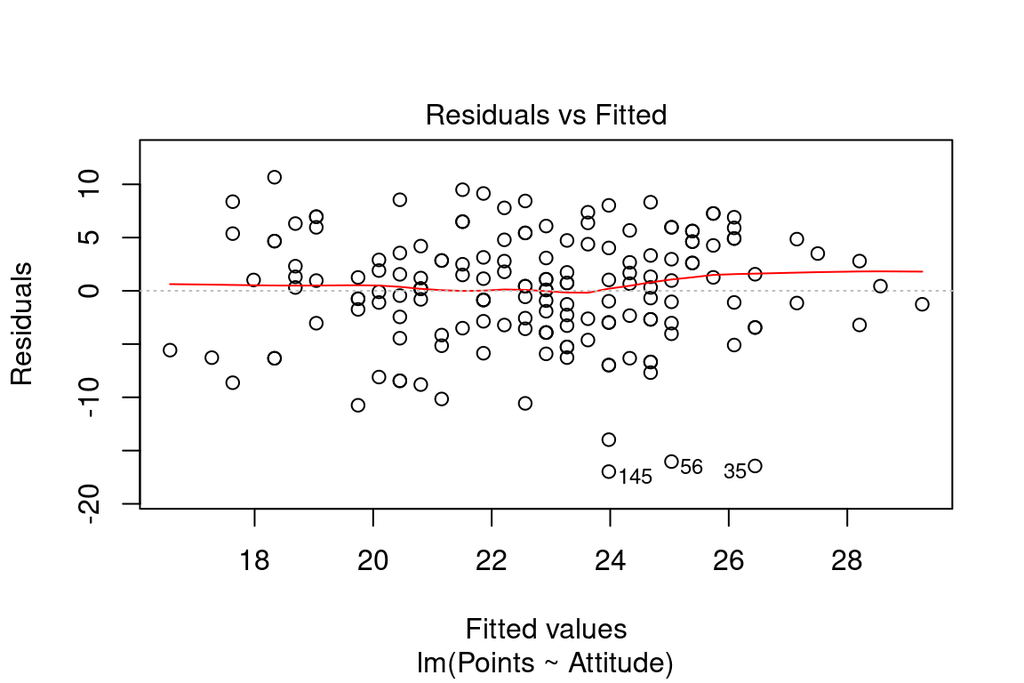

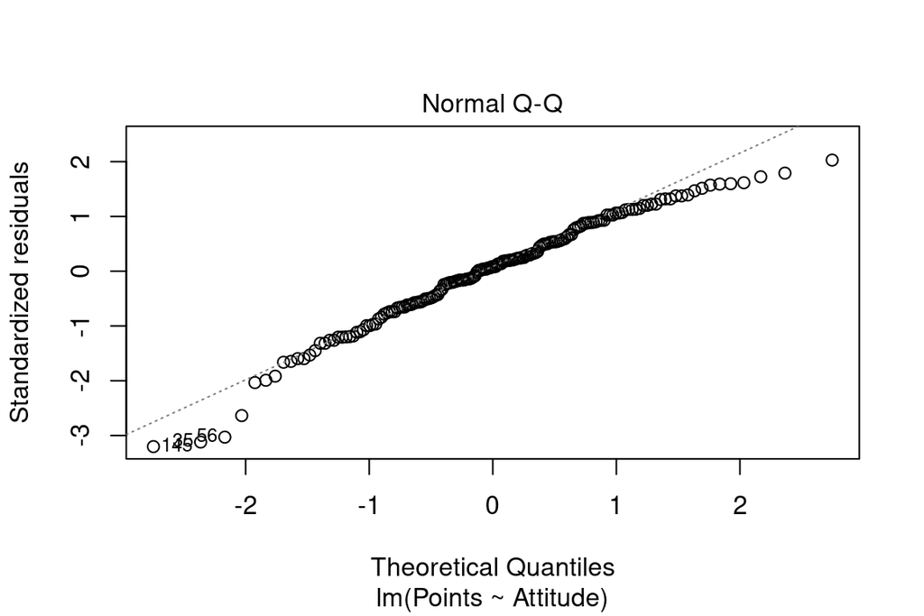

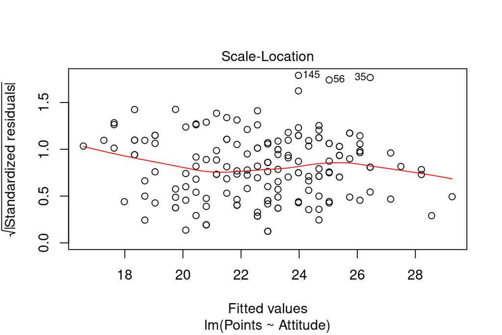

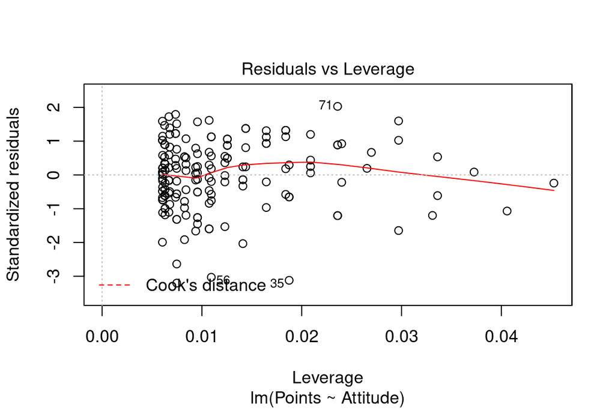

```r
plot(lm(Points~Attitude, data=learning2014))
```

# Chapter 3: Week 3 Logistic regression analysis

```r
library(data.table)

# Read in learning2014 created with create_learning2014.R
alc<-fread("data/alc.txt")
colnames(alc)
```

```
##  [1] "school"     "sex"        "age"        "address"    "famsize"
##  [6] "Pstatus"    "Medu"       "Fedu"       "Mjob"       "Fjob"
## [11] "reason"     "nursery"    "internet"   "guardian"   "traveltime"
## [16] "studytime"  "failures"   "schoolsup"  "famsup"     "paid"
## [21] "activities" "higher"     "romantic"   "famrel"     "freetime"
## [26] "goout"      "Dalc"       "Walc"       "health"     "absences"
## [31] "G1"         "G2"         "G3"         "alc_use"    "high_use"
```

This “Student Performance Data Set” dataset is derived from [UCI Machine learning repository](https://archive.ics.uci.edu/ml/datasets/Student+Performance). It’s described as:

“This data approach student achievement in secondary education of two Portuguese schools. The data attributes include student grades, demographic, social and school related features) and it was collected by using school reports and questionnaires. Two datasets are provided regarding the performance in two distinct subjects: Mathematics (mat) and Portuguese language (por). In [Cortez and Silva, 2008], the two datasets were modeled under binary/five-level classification and regression tasks. Important note: the target attribute G3 has a strong correlation with attributes G2 and G1. This occurs because G3 is the final year grade (issued at the 3rd period), while G1 and G2 correspond to the 1st and 2nd period grades. It is more difficult to predict G3 without G2 and G1, but such prediction is much more useful (see paper source for more details).”

We joined these two datasets (mat and por) together, overlapping variables were either averaged (quantitative) or the one from math selected (qualitative). Alc_use and high_use were calculated from the data.

# Analysis

Let’s select four variables for the analysis:

- Age (age is an usual suspect to be used as a covarate)
- Sex (Gender as well, probably alcohol consumption more usual among men)
- Mother’s education (Mother’s education is know to explain child’s education level)
- Going out with friends (Naturally affects alcohol consumption)

```r
vars<-c("age","sex","Medu","goout")
str(alc[,vars,with=F])
```

```
## Classes 'data.table' and 'data.frame':   382 obs. of  4 variables:
##  $ age  : int  18 17 15 15 16 16 16 17 15 15 ...
##  $ sex  : chr  "F" "F" "F" "F" ...
##  $ Medu : int  4 1 1 4 3 4 2 4 3 3 ...
##  $ goout: int  4 3 2 2 2 2 4 4 2 1 ...
##  - attr(*, ".internal.selfref")=<externalptr>
```

Age is a continuous variable, gender is dichotomous, mother’s education is multinomial, and going out is ordinal/continuous (likert).

```r
library(ggplot2)
library(GGally)
#ggpairs(alc, columns=c(vars,"high_use"))
```

## 1. Age

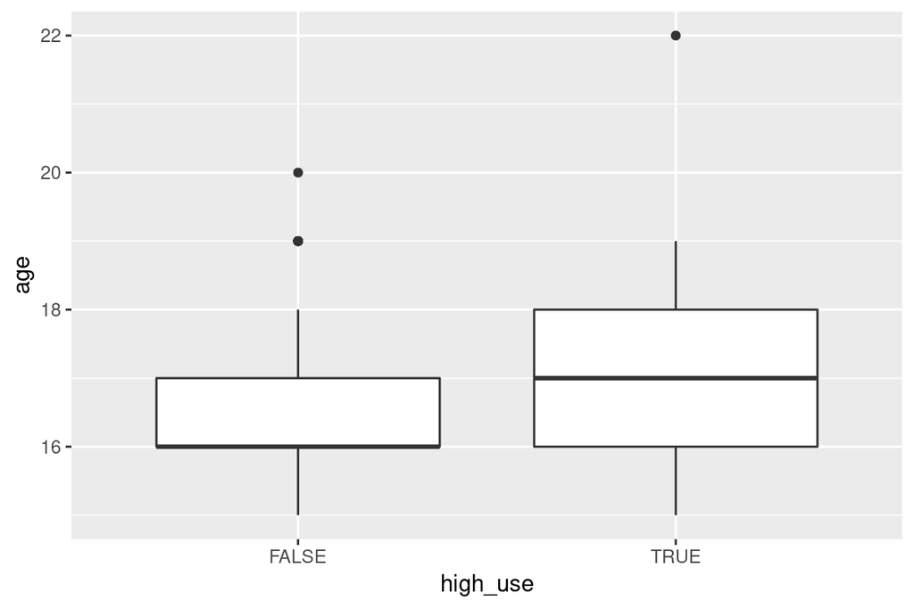

```r
library(ggridges)
library(magrittr)
library(dplyr)
ggplot(data=alc, aes(x=high_use, y=age)) + geom_boxplot()
```

```r
# Differenes in mean and standard deviation
alc %>% group_by(high_use) %>% summarise(mean_age=mean(age), sd_age=sd(age))
```

```
## # A tibble: 2 x 3
##   high_use mean_age sd_age
##   <lgl>       <dbl>  <dbl>
## 1 FALSE        16.5   1.15
## 2 TRUE         16.8   1.21
```

```r
# Univariate non-parametric test
wilcox.test(age~high_use, data=alc)
```

```
##
##  Wilcoxon rank sum test with continuity correction
##
## data:  age by high_use
## W = 13266, p-value = 0.05185
## alternative hypothesis: true location shift is not equal to 0
```

Distribution seems to be somewhat skewed, thus wilcox.test (mann-whitney). It indicates assocation, although not very strong: Older students are likely to have higher consumption which makes intuitive sense.

## 2. Gender

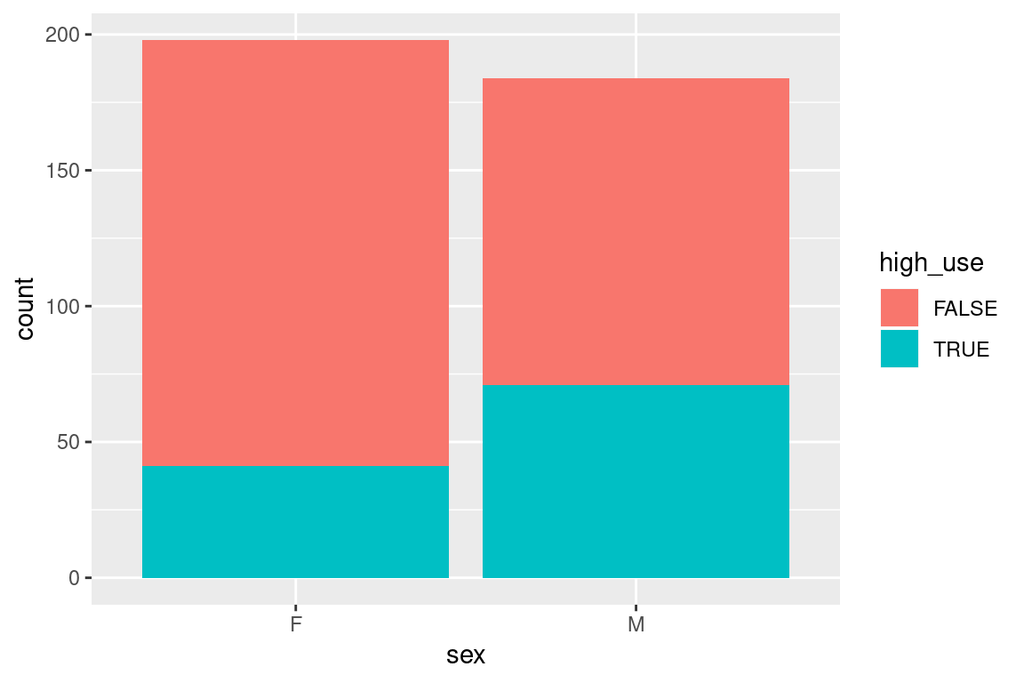

```r
ggplot(data=alc, aes(x=sex, fill=high_use)) + geom_bar()
```

```r
table(alc$high_use, alc$sex)
```

```
##
##           F   M
##   FALSE 157 113
##   TRUE   41  71
```

```r
chisq.test(x=alc$high_use, y=alc$sex)
```

```
##
##  Pearson's Chi-squared test with Yates' continuity correction
##
## data:  alc$high_use and alc$sex
## X-squared = 13.863, df = 1, p-value = 0.0001967
```

Gender seems to have strong univariate association as anticipated.

## 3. Mother’s education

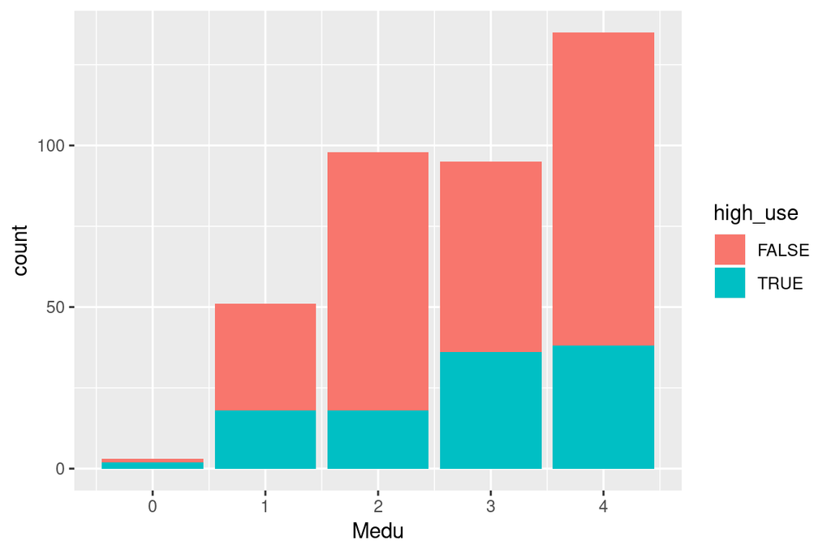

```r
ggplot(data=alc, aes(x=Medu, fill=high_use)) + geom_bar()
```

```r
table(alc$high_use, alc$Medu)
```

```
##
##          0  1  2  3  4
##   FALSE  1 33 80 59 97
##   TRUE   2 18 18 36 38
```

```r
chisq.test(y=alc$high_use, x=as.factor(alc$Medu))
```

```
##
##  Pearson's Chi-squared test
##
## data:  as.factor(alc$Medu) and alc$high_use
## X-squared = 12.031, df = 4, p-value = 0.01713
```

Mother’s education seems to associate slightly which we expected a priori.

## 4. Going out with friends (1-5)

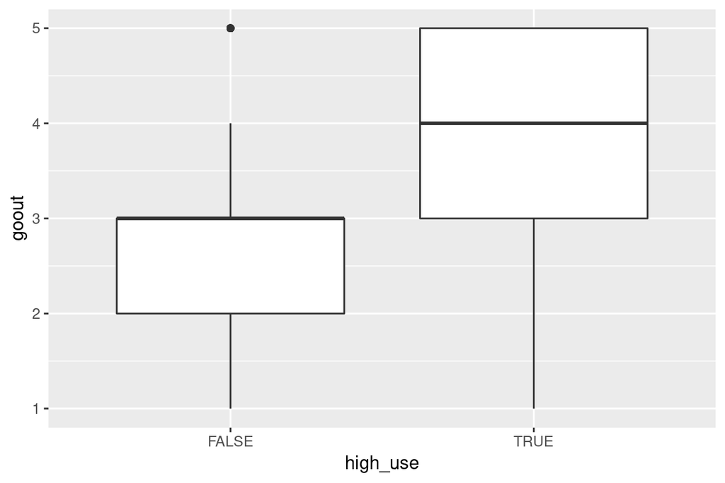

```r
ggplot(data=alc, aes(x=high_use, y=goout)) + geom_boxplot()
```

```r
# Differenes in mean and standard deviation
alc %>% group_by(high_use) %>% summarise(mean_age=mean(goout), sd_age=sd(goout))
```

```
## # A tibble: 2 x 3
##   high_use mean_age sd_age
##   <lgl>       <dbl>  <dbl>
## 1 FALSE        2.86   1.04
## 2 TRUE         3.73   1.10
```

```r
# Univariate non-parametric test
wilcox.test(goout~high_use, data=alc)
```

```
##
##  Wilcoxon rank sum test with continuity correction
##
## data:  goout by high_use
## W = 8577, p-value = 5.88e-12
## alternative hypothesis: true location shift is not equal to 0
```

“Going out” indiciates a strong univariate association, and makes naively sense.